# OOPS_5_Method Resolution Order (MRO)

#### Method Resolution Order (MRO):

- In Hybrid Inheritance the method resolution order is decided based on MRO algorithm.
- This algorithm is also known as C3 algorithm.
- Samuele Pedroni proposed this algorithm.
- It follows DLR (Depth First Left to Right) i.e Child will get more priority than Parent.
- Left Parent will get more priority than Right Parent.
- MRO(X) = X+Merge(MRO(P1),MRO(P2),...,ParentList)

#### Head Element vs Tail Terminology:

- Assume C1,C2,C3,...are classes.
- In the list: C1C2C3C4C5....
- C1 is considered as Head Element and remaining is considered as Tail.

#### How to find Merge:

- Take the head of first list
- If the head is not in the tail part of any other list, then add this head to the result and remove it from the lists in the merge.
- If the head is present in the tail part of any other list, then consider the head element of the next list and continue the same process.

Note: We can find MRO of any class by using mro() function.  
print(ClassName.mro())  
The python Method Resolution Order defines the class search path.

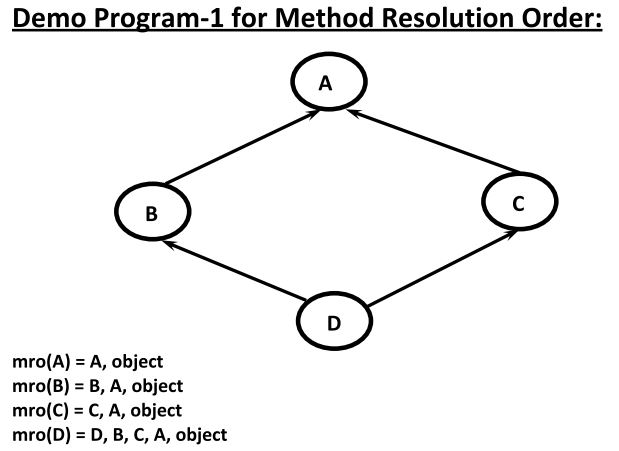

```python
class A():
    pass
class B(A):
    pass
class C(A):
    pass
class D(B,C):
    pass

print(A.mro())
print(B.mro())
print(C.mro())
print(D.mro())
```

```
[<class '__main__.A'>, <class 'object'>]
[<class '__main__.B'>, <class '__main__.A'>, <class 'object'>]
[<class '__main__.C'>, <class '__main__.A'>, <class 'object'>]
[<class '__main__.D'>, <class '__main__.B'>, <class '__main__.C'>, <class '__main__.A'>, <class 'object'>]
```

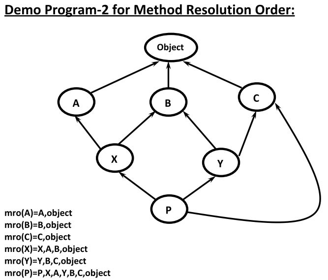

```python
class A():
    pass
class B():
    pass
class C():
    pass
class X(A,B):
    pass
class Y(B,C):
    pass
class P(X,Y,C):
    pass

print(A.mro())
print(B.mro())
print(C.mro())
print(X.mro())
print(Y.mro())
print(P.mro())
```

```
[<class '__main__.A'>, <class 'object'>]
[<class '__main__.B'>, <class 'object'>]
[<class '__main__.C'>, <class 'object'>]
[<class '__main__.X'>, <class '__main__.A'>, <class '__main__.B'>, <class 'object'>]
[<class '__main__.Y'>, <class '__main__.B'>, <class '__main__.C'>, <class 'object'>]
[<class '__main__.P'>, <class '__main__.X'>, <class '__main__.A'>, <class '__main__.Y'>, <class '__main__.B'>, <class '__main__.C'>, <class 'object'>]
```

```python
#Let check
class A():
    def m1(self):
        print('A class method')
class B():
    def m1(self):
        print('B class method')
class C():
    def m1(self):
        print('C class method')
class X(A,B):
    def m1(self):
        print('X class method')
class Y(B,C):
    def m1(self):
        print('Y class method')
class P(X,Y,C):
    def m1(self):
        print('P class method')

p=P()
p.m1()
help(p)
```

```
P class method
Help on P in module __main__ object:

class P(X, Y, C)
 |  Method resolution order:
 |      P
 |      X
 |      A
 |      Y
 |      B
 |      C
 |      builtins.object
 |  Methods defined here:
 |  m1(self)
 |  ----------------------------------------------------------------------
 |  Data descriptors inherited from A:
 |  __dict__
 |      dictionary for instance variables (if defined)
 |  __weakref__
 |      list of weak references to the object (if defined)
```

```python
class A():
    def m1(self):
        print('A class method')
class B():
    def m1(self):
        print('B class method')
class C():
    def m1(self):
        print('C class method')
class X(A,B):
    def m1(self):
        print('X class method')
class Y(B,C):
    def m1(self):
        print('Y class method')
class P(X,Y,C):
    pass

p=P()
p.m1()
```

```
X class method
```

```python
class A():
    def m1(self):
        print('A class method')
class B():
    def m1(self):
        print('B class method')
class C():
    def m1(self):
        print('C class method')
class X(A,B):
    pass
class Y(B,C):
    def m1(self):
        print('Y class method')
class P(X,Y,C):
    pass

p=P()
p.m1()
```

```
A class method
```

```python
class A():
    pass
class B():
    def m1(self):
        print('B class method')
class C():
    def m1(self):
        print('C class method')
class X(A,B):
    pass
class Y(B,C):
    def m1(self):
        print('Y class method')
class P(X,Y,C):
    pass

p=P()
p.m1()
```

```
Y class method
```

```python
class A():
    pass
class B():
    def m1(self):
        print('B class method')
class C():
    def m1(self):
        print('C class method')
class X(A,B):
    pass
class Y(B,C):
    pass
class P(X,Y,C):
    pass

p=P()
p.m1()
```

```
B class method
```

```python
class A():
    pass
class B():
    pass
class C():
    def m1(self):
        print('C class method')
class X(A,B):
    pass
class Y(B,C):
    pass
class P(X,Y,C):
    pass

p=P()
p.m1()
```

```
C class method
```

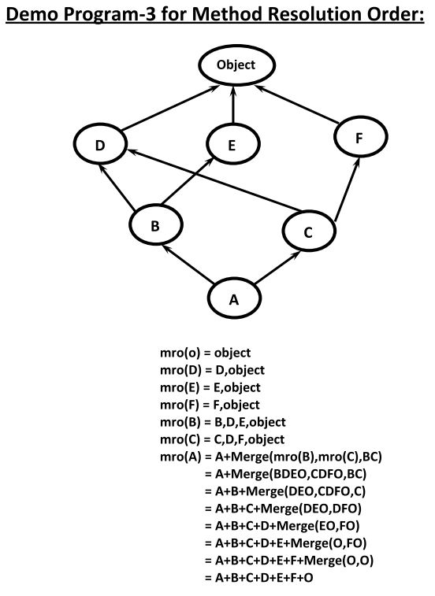

```python
class D():
    pass
class E():
    pass
class F():
    pass
class B(D,E):
    pass
class C(D,F):
    pass
class A(B,C):
    pass

print(D.mro())
print(E.mro())
print(F.mro())
print(B.mro())
print(C.mro())
print(A.mro())
help(A)
```

```
[<class '__main__.D'>, <class 'object'>]
[<class '__main__.E'>, <class 'object'>]
[<class '__main__.F'>, <class 'object'>]
[<class '__main__.B'>, <class '__main__.D'>, <class '__main__.E'>, <class 'object'>]
[<class '__main__.C'>, <class '__main__.D'>, <class '__main__.F'>, <class 'object'>]
[<class '__main__.A'>, <class '__main__.B'>, <class '__main__.C'>, <class '__main__.D'>, <class '__main__.E'>, <class '__main__.F'>, <class 'object'>]
Help on class A in module __main__:

class A(B, C)
 |  Method resolution order:
 |      A
 |      B
 |      C
 |      D
 |      E
 |      F
 |      builtins.object
 |  Data descriptors inherited from D:
 |  __dict__
 |      dictionary for instance variables (if defined)
 |  __weakref__
 |      list of weak references to the object (if defined)
```

#### How to Call Method of a Particular Super Class

##### super() Method:

super() is a built-in method which is useful to call the super class constructors,variables and methods from the child class.

```python
class Person():
    def __init__(self,name,age):
        self.name = name
        self.age = age

    def display(self):
        print('Name:',self.name)
        print('Age:',self.age)

class Student(Person):
    def __init__(self,name,age,rollno,marks):
        super().__init__(name,age)
        self.rollno = rollno
        self.marks = marks

    def display(self):
        super().display()
        print('Roll NUmber:',self.rollno)
        print('Marks:',self.marks)

s = Student('Rakesh',32,101,98)
s.display()
```

```
Name: Rakesh
Age: 32
Roll NUmber: 101
Marks: 98
```

```python
class P():
    a = 10
    def __init__(self):
        self.b = 20
    def m1(self):
        print('Parent Instance Method')

    @classmethod
    def m2(cls):
        print('Parent Class method')

    @staticmethod
    def m3():
        print('Parent static method')

class C(P):
    a = 888
    def __init__(self):
        self.b = 999
        super().__init__()
        print(super().a)
        super().m1()
        super().m2()
        super().m3()

c = C()
```

```
10
Parent Instance Method
Parent Class method
Parent static method
```

```python
class A():
    def m1(self):
        print('A class method')

class B(A):
    def m1(self):
        print('B class method')

class C(B):
    def m1(self):
        print('C class method')

class D(C):
    def m1(self):
        print('D class method')

class E(D):
    def m1(self):
        super().m1()

e = E()
e.m1()
```

```
D class method
```

```python
class A():
    def m1(self):
        print('A class method')

class B(A):
    def m1(self):
        print('B class method')

class C(B):
    def m1(self):
        print('C class method')

class D(C):
    def m1(self):
        print('D class method')

class E(D):
    def m1(self):
        super(C,self).m1()

e = E()
e.m1()
```

```
B class method
```

```python
class P:
    a = 10
    def __init__(self):
        self.b = 20
class C(P):
    a = 777
    def m1(self):
        print(super().a)
        print(self.b)
        print(self.a)


c = C()
c.m1()
```

```
10
20
777
```